# cmetcalf_OriginalHomeworkCode_02

Cat Metcalf

2023-09-25

# Peer Commentary:

- I LOVE your titi monkey picture! It’s such a mood.
- Don’t forget to include the five challenges you faced while completing this assignment.
- Consider writing a code to suppress the knitr::include_graphics(“Titimonkey.jpeg”) message in your RMD file. To do this, you can use the ‘echo’ option in the code chunk.
- Don’t forget to annotate and mark your code. You may want to repurpose this work in the future.
- R Challenge #6: Maybe the issue stems from your variable being set as “m” in the previous challenge? Consider trying hist(m, xlim = c(0,30, breaks = seq (1:30). This may also change your answer about how your histogram compares to the shape of the probability mass function plot.
- Note: To knit this RMD file I had to change your image from a “jpeg” to a “jpg”. Sorry about that.

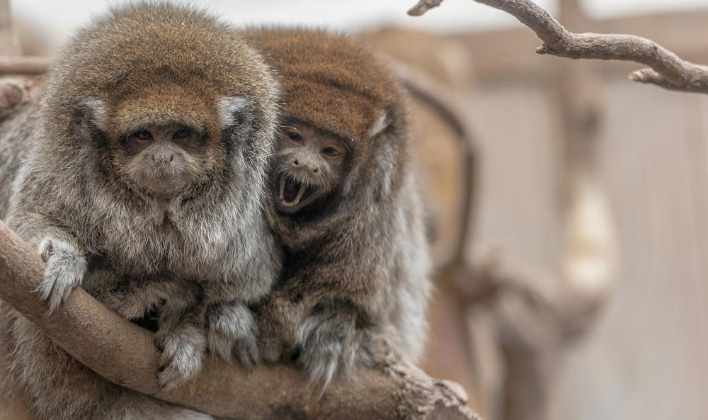

```r
knitr::include_graphics("Titimonkey.jpg")
```

# Titis in the Mist

Every Saturday morning, at the same time, a primatologist goes and sits in the forest to listen for titi monkey calls, counting the number of calls they hear in a 2 hour window from 5am to 7am. Based on previous knowledge, she believes that the mean number of calls she will hear in that time is exactly 15. Let X represent the appropriate Poisson random variable of the number of calls heard in each monitoring session.

## What is the probability that she will hear more than 8 calls during any given session?

```r
ppois(8, lambda=15, lower.tail = FALSE) #calculates probability of getting value greater than 8 within time interval
```

```
## [1] 0.9625535
```

## What is the probability that she will hear no calls in a session?

```r
x <-dpois(0, lambda=15) #0 indicates there are no calls in the time interval
x
```

```
## [1] 3.059023e-07
```

## What is the probability that she will hear exactly 3 calls in a session?

```r
dpois(3, lambda = 15)
```

```
## [1] 0.0001720701
```

## Plot the relevant Poisson mass function over the values in range 0 ≤ x ≤ 30.

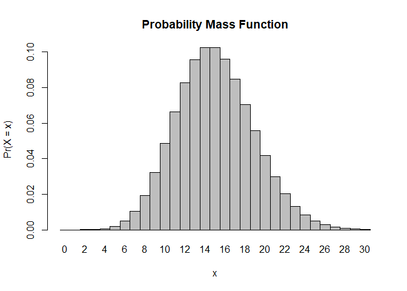

```r
x <- 0:30
l = 15
probset <- dpois(x = x, lambda = l)
barplot(probset, names.arg = x, space = 0, xlab = "x", ylab = "Pr(X = x)", main = "Probability Mass Function")
```

## Simulate 104 results from this distribution (i.e., 2 years of Saturday monitoring sessions).

```r
m <- rpois(104, lambda = 15)
m
```

```
##   [1] 16 15 14  8 13 21 16 10 24 15 12 20 10 13 20 13 22  9 15 16 13 18 21 14 12
##  [26] 16 17 19 19 17 18 17 17 17 16 14 10 25 18 19 17 22 11 16 16 21 15 20 24 10
##  [51] 21 15 12 21 12 14 20 15 15 20 16 15 12 15 12 15  9 27 15 18 16 17 11 13 20
##  [76] 19 16 13 11 16 16  9 20 26 11 10 17 13 18 16 23 18 15 14 21 15 14 10 17 13
## [101] 13 14 17 16
```

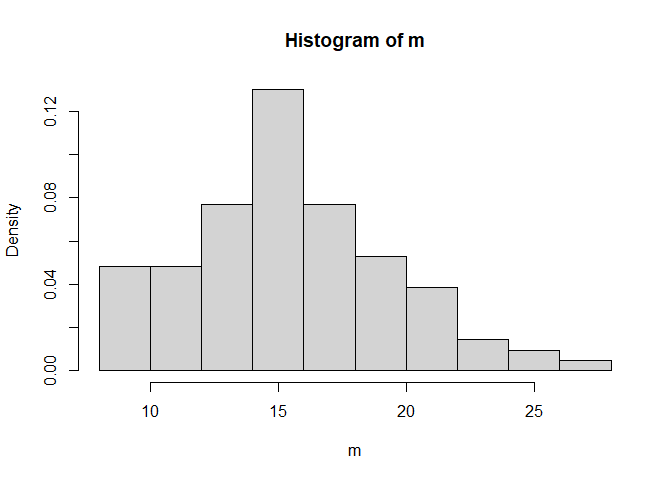

```r
z <-hist(m, probability = TRUE)
```

```r
z
```

```
## $breaks
##  [1]  8 10 12 14 16 18 20 22 24 26 28
##
## $counts
##  [1] 10 10 16 27 16 11  8  3  2  1
##
## $density
##  [1] 0.048076923 0.048076923 0.076923077 0.129807692 0.076923077 0.052884615
##  [7] 0.038461538 0.014423077 0.009615385 0.004807692
##
## $mids
##  [1]  9 11 13 15 17 19 21 23 25 27
##
## $xname
## [1] "m"
##
## $equidist
## [1] TRUE
##
## attr(,"class")
## [1] "histogram"
```